# Mean Shift Algorithm

The mean-shift algortithm is a clustering algorithm that assigns the datapoints to the clusters iteratively by shifting points towards the mode. This mode can be seen as the maxima of the probability density function.

This algorthm has been widely used for several image processing and computer vision tasks such as image denoising or image segmentation

# Algorithm

In order to find the cluster to which each sample corresponds, the **gradient ascent algorithm**. This method is applied to each of the points in the dataset and iterates the following steps until convergence or until a number of iterations is reached:

> 1. The mean shift vector is computed for the point $x^{(t)}$ :

>    > $m(x)^{(t)} = \frac{\sum_{i=0}^N K(||xi-x||^2) \cdot xi }{\sum_{i=0}^N K(||xi-x||^2)} - x^{(t)}$  
>    > where K() is the kernel applied to compute the algorithm
> 2. The position of the point is updated using the mean vector:

>    > $x^{(t+1)} = \frac{\sum_{i=0}^N K(||xi-x||^2) \cdot xi }{\sum_{i=0}^N K(||xi-x||^2)}$

The main Kernel used for this algorithm is the **Epanechnikov Kernel**, which simplfies the gradient ascent algortihm to computing the mean of the features in the neighborhood around x:

> K<sub>E</sub> $ = c \cdot (1-x^{T}x) $ if $ x^{T}x<1 $  
> $ x^{(t+1)} = \frac{1}{N} \sum_{i}^{N}x_i^{(t)} $

```python
import os, time
import numpy as np
from PIL import Image
from matplotlib import pyplot as plt
from sklearn.datasets.samples_generator import make_blobs

import mean_shift as mean_shift
```

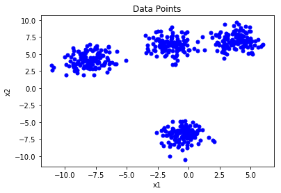

```python
# obtaining and displaying our data
original_data, _ = make_blobs(500, 2, centers=4, cluster_std=1)

ax = plt.gca()
im, = ax.plot( original_data[:,0], original_data[:,1], "bo", markersize=5)
ax.set_title("Data Points")
ax.set_xlabel("x1")
ax.set_ylabel("x2")
plt.show()
```

```python
# computing one iteration of the algorithm
def iterate_data( data, thr=3 ):

    new_data = np.copy(data)

    #iterating all data points
    for i,x in enumerate(data):

        points_in_neighborhood = []

        for y in data:

            # computing the neighbors of the given point
            if( not mean_shift.is_point_in_neighborhood(center=x, y=y, thr=thr) ):
                continue
            else:
                points_in_neighborhood.append(y)

        # updating the centers using the epanechnikov kerner
        # => average of all feature vectors
        new_data[i] = np.sum(np.array(points_in_neighborhood),axis=0)/len(points_in_neighborhood)

    return new_data


# computing several iterations of the mean shift algorithm
def mean_shift_algorithm(data, num_iterations=4, thr=3):

    centers = np.copy(data)

    fig, ax = plt.subplots(2,2)
    fig.set_size_inches(8, 8)

    # iterating a given number of times
    for i in range(num_iterations):

        # computign the iteration steps
        centers = iterate_data( centers, thr=3 )

        # visualizing the results
        x = int(np.floor(i/2))
        y = i%2

        im, = ax[x,y].plot( data[:,0], data[:,1], "bo", markersize=5, label="data")
        im.set_label("data")
        im, = ax[x,y].plot( centers[:,0], centers[:,1], "ro", markersize=5, label="center")
        im.set_label("center")
        ax[x,y].set_title(f"Data after {i+1} iterations")
        ax[x,y].set_xlabel("x1")
        ax[x,y].set_ylabel("x2")

        ax[x,y].legend()

    plt.tight_layout()
    plt.show()

    return centers, data
```

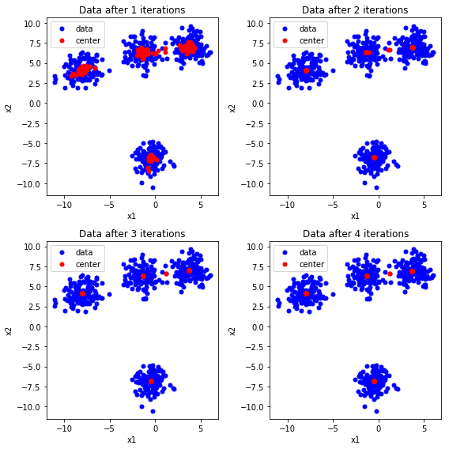

```
Duration: 4.9658379554748535
```

```python
start_time = time.time()
centers,_ = mean_shift_algorithm(original_data, num_iterations=4, thr=3)
end_time = time.time()
print(f"Duration: {end_time-start_time} ")
```

# Efficient Implementation

The previous implementation is nice didactically, as it shows step-by-step how the algorithm works. Unfortunatelly, it is not efficient at all.

By vectorizing some operations such as computing the neighbors, the performance can be highly improved

```python
# obtaining the neighbors in a vectorized manner
def get_neighbors( center, points, thr=3 ):

    n_points = len(points)

    # creating a matrix by repeating our currnet center
    matrix_point = np.tile( center, (n_points,1) )

    # computing the row-wise distance of the matrix
    distance = np.linalg.norm( matrix_point-points, ord=2, axis=1 )

    # thresholding and obtaining the neighbors
    idx = np.where( distance<=thr )[0]
    neighbors = points[idx,:]

    return neighbors


# iterating the data in a more efficient way
def iterate_data( data, thr=3 ):

    new_data = np.copy(data)

    for i,data_point in enumerate(data):

        # obtaining neighbors
        neighbors = get_neighbors( data_point, data, thr=thr )
        # averaging values
        n_neighbors = len(neighbors)
        mean_value =  np.sum(neighbors,axis=0)/n_neighbors

        new_data[i] = mean_value

    return new_data


# computing several iterations of the mean shift algorithm
def mean_shift_algorithm(data, num_iterations=4, thr=3):

    centers = np.copy(data)

    fig, ax = plt.subplots(2,2)
    fig.set_size_inches(8, 8)

    # iterating a given number of times
    for i in range(num_iterations):

        # computign the iteration steps
        centers = iterate_data( centers, thr=thr )

        # visualizing the results
        x = int(np.floor(i/2))
        y = i%2

        im, = ax[x,y].plot( data[:,0], data[:,1], "bo", markersize=5, label="data")
        im.set_label("data")
        im, = ax[x,y].plot( centers[:,0], centers[:,1], "ro", markersize=5, label="center")
        im.set_label("center")
        ax[x,y].set_title(f"Data after {i+1} iterations")
        ax[x,y].set_xlabel("x1")
        ax[x,y].set_ylabel("x2")
        ax[x,y].legend()

    plt.tight_layout()
    plt.show()

    return centers, data
```

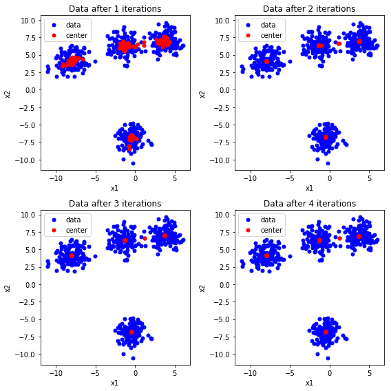

```
Duration: 0.49097323417663574
```

```python
start_time = time.time()
centers, data = mean_shift_algorithm(original_data, num_iterations=4, thr=3)
end_time = time.time()
print(f"Duration: {end_time-start_time} ")
```

# Model Selection

The choice of kernel parameters is of vital importance. A too large distance threshold might merge different clusters, whereas a distance that is too small might overfit the visible data by creating too many clusters.

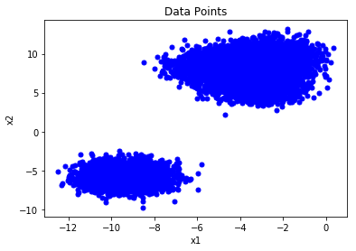

```python
# obtaining and displaying our data
original_data, _ = make_blobs(10000, 2, centers=4, cluster_std=1)

ax = plt.gca()
im, = ax.plot( original_data[:,0], original_data[:,1], "bo", markersize=5)
ax.set_title("Data Points")
ax.set_xlabel("x1")
ax.set_ylabel("x2")
plt.show()
```

```
Duration: 44.26759958267212
```

```
No handles with labels found to put in legend.
```

```
Duration: 30.845060348510742
```

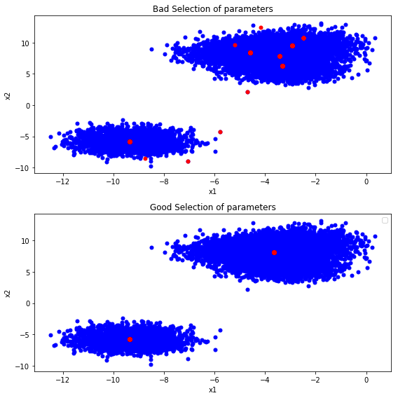

```python
start_time = time.time()
centers_1,_ = mean_shift.mean_shift(original_data, num_iterations=10, thr=1, kernel="epanechnikov")
end_time = time.time()
print(f"Duration: {end_time-start_time} ")
# visualizing the results
plt.figure(figsize=(8,8))
plt.subplot(211)

ax = plt.gca()
im, = ax.plot( original_data[:,0], original_data[:,1], "bo", markersize=5)
im, = ax.plot( centers_1[:,0], centers_1[:,1], "ro", markersize=5)
ax.set_title("Bad Selection of parameters")
ax.set_xlabel("x1")
ax.set_ylabel("x2")

start_time = time.time()
centers_2,_ = mean_shift.mean_shift(original_data, num_iterations=5, thr=3, kernel="epanechnikov")
end_time = time.time()
print(f"Duration: {end_time-start_time} ")

# visualizing the results
plt.subplot(212)
ax = plt.gca()
im, = ax.plot( original_data[:,0], original_data[:,1], "bo", markersize=5)
im, = ax.plot( centers_2[:,0], centers_2[:,1], "ro", markersize=5)
ax.set_title("Good Selection of parameters")
ax.set_xlabel("x1")
ax.set_ylabel("x2")

plt.legend()
plt.tight_layout()
plt.show()
```

# Denoising

The mean-shift algoritm can also be used for denoising. For this task, a small kernel is prefered; this way, small clusters with noisy points will converge to the same mean. The colors of the points converging to the same mean will be averaged, thus producing a denoising effect.

The feature vector used is a 5-dimensional vector containing: $(X,Y,L,U,V)$. The LUV color space is prefered over RGB as the later is not consistent with norms and euclidean distances.

It is also important to note that these features are not in the same scale. While LUV values are bounded by 100, the $(x,y)$ coordinates can have quite large values. Therefore, feature normalization is a vital task.

Due to the poor performance of the algorithm, it might not be optimal to perform denoising in large images.

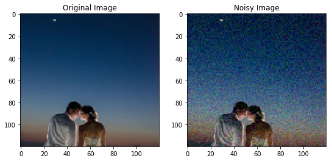

```python
# loading the original data and adding the noise
img_path = os.path.join(os.getcwd(),"images")
img_name = "sunset.jpg"

img = Image.open( os.path.join(img_path,img_name) )
img = np.array(img, dtype=np.uint8)

# creating a noisy image by applying noise to the original image
NOISE_STD = 15
noise = np.random.randn(img.shape[0],img.shape[1],img.shape[2])
noise = np.rint(noise*NOISE_STD)
noisy_image = img+noise
noisy_image = np.clip( noisy_image, a_min=0, a_max=255)
noisy_image = np.array( noisy_image, dtype=np.uint8 )

plt.figure(figsize=(9,4))
plt.subplot(1,2,1)
plt.imshow(img, aspect="auto")
plt.title("Original Image")
plt.subplot(1,2,2)
plt.imshow(noisy_image, aspect="auto")
plt.title("Noisy Image")
plt.show()
```

```python
# method that creates the (X,Y,L,U,V) feature vector
def create_feature_vectors( img ):

    xaxis = np.arange( img.shape[1] )
    yaxis = np.arange( img.shape[0] )
    x,y = np.meshgrid(xaxis,yaxis)
    x = x.flatten()
    y = y.flatten()

    img = mean_shift.rgb_to_luv(img)

    l_vector = img[:,:,0].flatten()
    u_vector = img[:,:,1].flatten()
    v_vector = img[:,:,2].flatten()

    n_vectors = len(x)
    feature_vectors = np.zeros((n_vectors,5))

    feature_vectors[:,0] = x
    feature_vectors[:,1] = y
    feature_vectors[:,2] = l_vector
    feature_vectors[:,3] = u_vector
    feature_vectors[:,4] = v_vector

    return feature_vectors


# method that normalizes each of the dimensions to 0 mean and unit variance
def normalize_feature_vectors( feature_vectors, weights=[] ):

    if( len(weights)==0 ):
        weights = np.ones(feature_vectors[0].shape)

    means = []
    variances = []
    normalized_feature_vectors = np.copy(feature_vectors)

    for i in range( feature_vectors.shape[1] ):

        mean = np.mean( feature_vectors[:,i] )
        variance = np.var( feature_vectors[:,i] )

        eps = 1e-8
        normalized_feature_vectors[:,i] -= mean
        normalized_feature_vectors[:,i] /= (variance+eps)
        normalized_feature_vectors[:,i] *= weights[i]

        means.append(mean)
        variances.append(variance)

    return normalized_feature_vectors, means, variances
```

```python
def assign_points_to_clusters(points, feature_vectors, thr=1e-10):

    clusters = {}

    # grouping all points that belong to the same cluster
    # we use a dictionary as data structure
    for i, point in enumerate(points):

        # obtaining the already found centers
        keys = list(clusters.keys())
        centers = np.array(keys,dtype=np.float)

        l2_norm = np.linalg.norm(point, ord=2)
        current_feature_vector = feature_vectors[i,:]

        #initializing the dictionary in the first case
        if(len(keys)==0):
            clusters[l2_norm] = np.array([feature_vectors[i,:]])
            continue

        # checking to which cluster the current point belongs
        substraction = (l2_norm-centers)
        distances = np.linalg.norm( substraction[:,np.newaxis], ord=2, axis=1)
        idx = np.where(distances<=thr)[0]

        if(len(idx)==0):
            clusters[l2_norm] = np.array([feature_vectors[i,:]])
        else:
            idx = idx[0]
            clusters[keys[idx]] = np.concatenate((clusters[keys[idx]], current_feature_vector[np.newaxis,:] ), axis=0)

    return clusters
```

```python
# obtaining the feature vectors and normalizing the dimensions
feature_vectors = create_feature_vectors( noisy_image )

# this weights force the clustering of nearby points
weights = np.array([10,10,1,1,1])
normalized_feature_vectors, means, variances = normalize_feature_vectors( feature_vectors, weights = weights )
```

```python
kernel = "gaussian"
points,_ = mean_shift.mean_shift(normalized_feature_vectors, num_iterations=8, thr=0.04, kernel=kernel, sigma=20)
```

```python
# assigning points to the clusters
clusters = assign_points_to_clusters(points, feature_vectors)
```

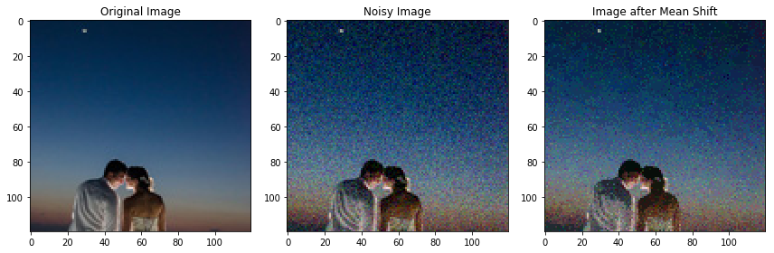

```python
keys = list(clusters.keys())
denoised_image = np.zeros(img.shape, dtype=np.uint8)

# averaging colors for every cluster and assigning
for i,key in enumerate(keys):

    points_in_current_cluster = clusters[key]

    y = np.array(points_in_current_cluster[:,0], dtype=np.int)
    x = np.array(points_in_current_cluster[:,1], dtype=np.int)
    l_mean = int(np.round(np.mean(points_in_current_cluster[:,2])))
    u_mean = int(np.round(np.mean(points_in_current_cluster[:,3])))
    v_mean = int(np.round(np.mean(points_in_current_cluster[:,4])))

    denoised_image[x,y,0] = l_mean
    denoised_image[x,y,1] = u_mean
    denoised_image[x,y,2] = v_mean

# converting back to the RGB color space
denoised_image = mean_shift.luv_to_rgb(denoised_image)

# visualization
plt.figure(figsize=(12,4))
plt.subplot(1,3,1)
plt.imshow(img, aspect="auto")
plt.title("Original Image")
plt.subplot(1,3,2)
plt.imshow(noisy_image, aspect="auto")
plt.title("Noisy Image")
plt.subplot(1,3,3)
plt.imshow(denoised_image, aspect="auto")
plt.title("Image after Mean Shift")
plt.tight_layout()
plt.show()
```

```
Obtaining feature vectors
Normalizing feature vectors
Computing mean shift algorithm
```

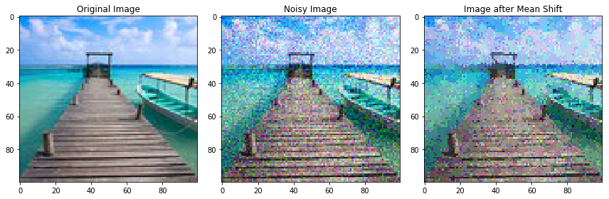

```python
# loading the original data and adding the noise
img_path = os.path.join(os.getcwd(),"images")
img_name = "island.jpg"

img = Image.open( os.path.join(img_path,img_name) )
img = np.array(img, dtype=np.uint8)

# creating a noisy image by applying noise to the original image
NOISE_STD = 30
noise = np.random.randn(img.shape[0],img.shape[1],img.shape[2])
noise = np.rint(noise*NOISE_STD)
noisy_image = img+noise
noisy_image = np.clip( noisy_image, a_min=0, a_max=255)
noisy_image = np.array( noisy_image, dtype=np.uint8 )

weights = np.array([10,10,1,1,1])

denoised_image = mean_shift.mean_shift_denoising( noisy_image, num_iterations=8, weights=weights,
                                                 thr=0.033, kernel="gaussian", sigma=20 )

plt.figure(figsize=(12,4))
plt.subplot(1,3,1)
plt.imshow(img, aspect="auto")
plt.title("Original Image")
plt.subplot(1,3,2)
plt.imshow(noisy_image, aspect="auto")
plt.title("Noisy Image")
plt.subplot(1,3,3)
plt.imshow(denoised_image, aspect="auto")
plt.title("Image after Mean Shift")
plt.tight_layout()
plt.show()
```

# Segmentation

Image segmentation is the process of partitioning an image into multiple segments or super-pixels. This partitioning can be done regarding boundaries, colors or other features of the image.

The mean-shift algorithm can be used to perform image segmentation in a similar process to the one we used for denoising.

For this particular case, we use a 3-dimensional vector containing: $(R,G,B)$ or $(L,U,V)$. The objects that share a similar color will join the same cluster, therofore being segmented into the same superpixel.

```
Obtaining feature vectors
Normalizing feature vectors
Computing mean shift algorithm
```

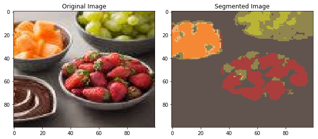

```python
img_path = os.path.join(os.getcwd(),"images")
img_name = "fruit.jpg"

img = Image.open( os.path.join(img_path,img_name) )
img = np.array(img, dtype=np.uint8)

weights = np.array([1,2,2])
segmented_image = mean_shift.mean_shift_segmentation( img, num_iterations=8, weights=weights,
                                                 thr=0.06, kernel="gaussian", sigma=10 )

plt.figure(figsize=(9,4))
plt.subplot(1,2,1)
plt.imshow(img, aspect="auto")
plt.title("Original Image")
plt.subplot(1,2,2)
plt.imshow(segmented_image, aspect="auto")
plt.title("Segmented Image")
plt.tight_layout()
plt.show()
```

```
Obtaining feature vectors
Normalizing feature vectors
Computing mean shift algorithm
```

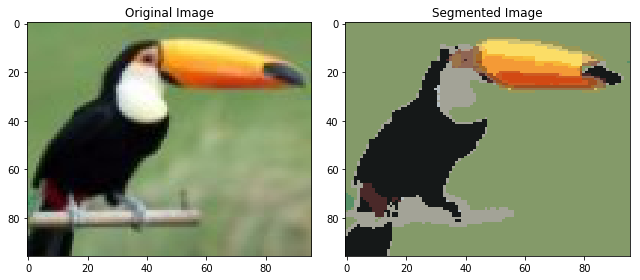

```python
img_path = os.path.join(os.getcwd(),"images")
img_name = "tucan.jpg"

img = Image.open( os.path.join(img_path,img_name) )
img = np.array(img, dtype=np.uint8)

weights = np.array([1.5,2,2])
segmented_image = mean_shift.mean_shift_segmentation( img, num_iterations=8, weights=weights,
                                                 thr=0.06, kernel="gaussian", sigma=10 )

plt.figure(figsize=(9,4))
plt.subplot(1,2,1)
plt.imshow(img, aspect="auto")
plt.title("Original Image")
plt.subplot(1,2,2)
plt.imshow(segmented_image, aspect="auto")
plt.title("Segmented Image")
plt.tight_layout()
plt.show()
```

### This notebook was developed by Angel Villar-Corrales